# Agricultural Data Visualization using R

Jaskaran Dhiman

### Why R?

- Open source programming language
- Availability of wide range of packages - Powerful
- Interactive plots (RShiny)
- Highly customizable data visualization
- Machine learning (ML) operations

### R vs RStudio

- R is a programming language, whereas RStudio is an Integrated Development Environment (IDE)
- RStudio provides the user interface for effective use of R

### Assumptions

Students have taken my previous class on:

- Introduction to R
- RStudio Environment
- Installing packages
- Syntax (especially ggplot2 package)
- Use of R Notebooks

### Helpful Resources

The following Github repository contains the code used for this class, the data, as well as documents containing instructions on installation of R and RStudio:

https://github.com/jasdhiman/AgData_analysis

### Data Source

United Nations FAOSTAT dataset (modified for this exercise):

- Global Food and Agricultural Statistics

Obtained from the following website:

- https://www.kaggle.com/datasets/unitednations/global-food-agriculture-statistics

Original data link:

http://data.un.org/Explorer.aspx

### Importing Data

Getting the required resources (loading libraries)

```r
library(tidyverse)
```

Reading data and saving as a data frame

```r
cropdata <- read.csv('fao_data_crops_data.csv')
```

#### Data Exploration and Cleaning

Getting column names

```r
colnames(cropdata)
```

Getting unique values and assigning it to a dataframe

```r
cropdata %>%
  distinct(country_or_area) -> regions
```

Getting number of unique or distinct values for a specific variable

```r
n_distinct(cropdata['country_or_area'])
n_distinct(cropdata$country_or_area)
```

Getting number of unique values for each variable / column using ‘for loop’

```r
# for loop example

for (i in colnames(cropdata)) {
  print(paste('number of unique values for variable ', i,  ' are: ', n_distinct(cropdata[i]), sep = ''))
}
```

Exploring unique values for years

```r
cropdata %>%
  distinct(year)
```

Exploring unique values for parameters

```r
cropdata %>%
  distinct(element)
```

Different parameters must have different units, let us see

```r
cropdata %>%
  distinct(unit)
```

Which parameters have which units (distinct combination of specified parameters)

```r
cropdata %>%
  distinct(element, unit)
```

We can combine the 2 columns: element and the unit

```r
# we will use MUTATE function
  # mutate is used to create, delete, or modify columns

cropdata %>%
  mutate(parameter = paste(element, unit, sep = '_'), element = NULL, unit = NULL) -> cropdata2
```

I want to extract data from this global data-set, that satisfies the following condition:

- Countries: Canada, USA, India, UK, France, Mexico, Portugal, Germany
- years: 1991 - 2000
- only area and production as parameters

We will use “filter” function for this

```r
countries <- c('Canada', 'India', 'Germany', 'Portugal', 'Mexico', 'United Kingdom', 'United States of America', 'France')

req_years <- 1991:2000

req_parameters <- c('Area Harvested_Ha', 'Production Quantity_tonnes')

# use filter and in operator %in%
cropdata2 %>%
  filter(country_or_area %in% countries &
           year %in% req_years &
           parameter %in% req_parameters) -> cropdata3
```

The parameters are in the long form (melted form), let us convert the data frame into wide form (spread form)

we need two columns for this:

- one variable who’s levels will form the new columns (parameter)
- one variable that will provide the value to these new variable (value)

```r
cropdata3 %>%
  spread(parameter, value) -> cropdata4
```

Let us calculate yield (tonnes/ha)

```r
cropdata4 %>%
  mutate(yield = (`Production Quantity_tonnes`/`Area Harvested_Ha`)) -> cropdata5
```

There are some rows containing ‘NA’ values

for the sake of today’s exercise, let us delete those

```r
# checking NA values using summary
  # summary also gives the basic univariate analysis of variables
summary(cropdata5)

# deleting rows with NA values
cropdata6 <- drop_na(cropdata5)

summary(cropdata6)
```

```r
# removing rows with area = 0
cropdata6 %>%
  filter(`Area Harvested_Ha` != 0) -> cropdata7

summary(cropdata7)
```

### Data Visualization

- Assumption: students are aware with the basic syntax

Now let us plot some figures

Histogram

```r
cropdata7 %>%
  ggplot(aes(x=yield)) +
  geom_histogram()
```

Histogram with user-defined bins

```r
cropdata7 %>%
  ggplot(aes(x=yield)) +
  geom_histogram(bins = 100)
```

Other method to visualize distribution - Boxplots

```r
# geometry changed from histogram to boxplot
cropdata7 %>%
  ggplot(aes(x=yield)) +
  geom_boxplot()
```

- Any thoughts why?

Taking one crop as an example

- Select a crop that is widely grown
  - Do a frequency analysis for this

```r
# use frequency table to make a selection
table(cropdata7$category)

# visualizing the frequency plot
  # using bar as the geometry
cropdata7 %>%
  ggplot(aes(x=category)) +
  geom_bar(stat = 'count')
```

Let us go with ‘grapes’ and see the distribution of yield

```r
# use x or y for horizontal or vertical plots respectively
cropdata7 %>%
  filter(category == 'grapes') %>%
  ggplot(aes(y = yield)) +
  geom_boxplot()
```

Let us improve the visualization a bit

Viewing results for different countries

```r
# saving the figure to an R object
cropdata7 %>%
  filter(category == 'grapes') %>%
  ggplot(aes(x = country_or_area, y = yield)) +
  geom_boxplot() -> temp_plot

# viewing
temp_plot
```

How can we fix the labels?

Fixing axis labels

```r
# rotating the text
temp_plot +
  theme(axis.text.x = element_text(angle = 90))
```

Further fixing the labels

```r
# horizontal and vertical adjustment of the text
temp_plot +
  theme(axis.text.x = element_text(angle = 90, hjust = 1, vjust = 0.3))
```

Reordering by increasing values - reorder function

```r
cropdata7 %>%
  filter(category == 'grapes') %>%
  ggplot(aes(x = reorder(country_or_area, yield), y = yield)) +
  geom_boxplot() +
  theme(axis.text.x = element_text(angle = 90, hjust = 1, vjust = 0.3))
```

Reordering with decreasing value (highest first)

```r
# use a negative sign
cropdata7 %>%
  filter(category == 'grapes') %>%
  ggplot(aes(x = reorder(country_or_area, -yield), y = yield)) +
  geom_boxplot() +
  theme(axis.text.x = element_text(angle = 90, hjust = 1, vjust = 0.3)) -> temp_plot

#viewing
temp_plot
```

Adding labels

```r
# using ggtitle, xlab and ylab functions
temp_plot +
  ggtitle('Distribution of Grape Yields Across Selected Countries (tonnes/Ha)') +
  ylab('Yield (tonnes/Ha)') +
  xlab('Country')
```

Adding some colours

```r
# using the color, fill, and alpha argument in the boxplot function
cropdata7 %>%
  filter(category == 'grapes') %>%
  ggplot(aes(x = reorder(country_or_area, -yield), y = yield)) +
  geom_boxplot(color = 'black', fill = 'green', alpha = 0.2) +
  theme(axis.text.x = element_text(angle = 90, hjust = 1, vjust = 0.3)) +
  ggtitle('Distribution of Grape Yields Across Selected Countries, 1991-2000 (tonnes/Ha)')+
  ylab('Yield (tonnes/Ha)') +
  xlab('Country')
```

Adding colors - different for each class

```r
# use 'fill' command to define a class in ggplot line
cropdata7 %>%
  filter(category == 'grapes') %>%
  ggplot(aes(x = reorder(country_or_area, -yield), y = yield, fill = country_or_area)) +
  geom_boxplot(alpha = 0.2) +
  theme(axis.text.x = element_text(angle = 90, hjust = 1, vjust = 0.3)) +
  ggtitle('Distribution of Grape Yields Across Selected Countries, 1991-2000 (tonnes/Ha)')+
  ylab('Yield (tonnes/Ha)') +
  xlab('Country') -> temp_plot

#viewing
temp_plot
```

Modifying legend in the above graph

```r
# defining position of the legend by using legend.position argument
temp_plot +
  theme(legend.position = "bottom")
```

However, use of legend is redundant here, so we remove legend

```r
temp_plot +
  theme(legend.position = "none") -> temp_plot

#viewing
temp_plot
```

What if we need higher resolution y-axis labels

```r
# use scale_y_continous function with user defined values
temp_plot +
  scale_y_continuous(breaks = seq(0, 30, by = 2)) -> temp_plot

#viewing
temp_plot
```

Adding mean values on top of boxplots

```r
# use stat summary function along the y-axis
temp_plot +
  stat_summary(fun = "mean", color = 'red', size = 0.3) -> temp_plot

# viewing
temp_plot
```

Saving the plot

```r
ggsave("grapes.png", temp_plot)
```

Performing a pairwise t-test analysis

```r
# use pairwise t test function
cropdata7 %>%
  filter(category == 'grapes') -> ttestdata

pairwise.t.test(ttestdata$yield, ttestdata$country_or_area)
```

Looking at production trends for Canada

- Use of line plots

```r
# geom_line function
cropdata7 %>%
  filter(category == 'grapes' & country_or_area == 'Canada') %>%
  ggplot(aes(x = year, y = yield)) +
  geom_line()
```

Here, year is considered as continuous numeric variable. We want it as a discrete variable

- Using Factor() function for this

```r
cropdata7 %>%
  filter(category == 'grapes' & country_or_area == 'Canada') %>%
  ggplot(aes(x = factor(year), y = yield, group=1)) +
  geom_line() -> temp_plot

# group = 1 is used to tell R that only 1 group is present to draw 1 line

# viewing
temp_plot
```

Adding points along with the line

- shape, colour, and fill of the point can be defined

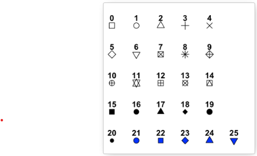

```r
# using geom_point function
temp_plot +
  geom_point(shape=23, fill="red", color = "black", size=3) -> temp_plot

# viewing
temp_plot
```

Adding labels

```r
temp_plot +
  ggtitle('Grape Yield (tonnes/Ha) Trend in Canada (1991-2000)') +
  ylab('Yield (tonnes/Ha)') +
  xlab('Year')
```

How can we develop a similar graph for each country separately?

Using loops to get the required plots

```r
# first we get the distinct countries in a dataset
cropdata7 %>%
  distinct(country_or_area) -> countries

# viewing
countries
```

Now we use loop to develop the required graphs

```r
for (i in countries$country_or_area) {
  cropdata7 %>%
    filter(category == 'grapes' & country_or_area == i) %>%
    ggplot(aes(x = factor(year), y = yield, group=1)) +
    geom_line() +
    geom_point(shape=23, fill="red", color = "black", size=3) +
    ggtitle(paste('Grape Yield (tonnes/Ha) Trend in ', i, ' (1991-2000)', sep = '')) +
    ylab('Yield (tonnes/Ha)') +
    xlab('Year') -> temp_plot
  # saving
  ggsave(paste('grape_', i, '.png', sep = ""), temp_plot)
}
```

[figure not shown]

Assignment: Grid plot showing yield trends for apple, barley and grapes for the following countries:

- Canada
- USA
- India

  hint: use facet_grid function - you will get 9 plots in a single image

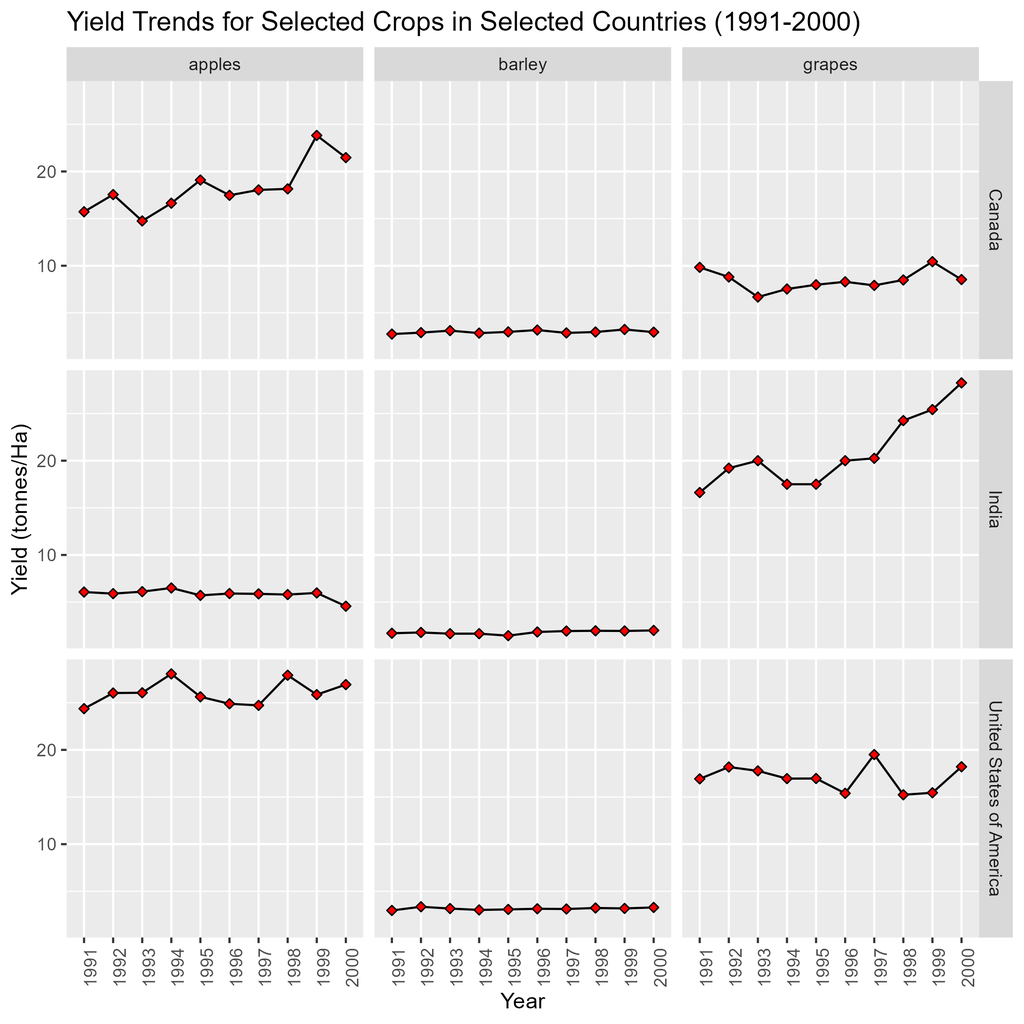

### Complete Analysis

Code and associated files can be found on my Github repository:

https://github.com/jasdhiman/AgData_analysis

- The code for lecture class
- Code for complete analysis
  - scatter plots
  - bar plots
  - error bars
  - model fitting
  - equation of the line of best fit
  - plotting a user-specified line on a graph
- Data used for analysis

### Other resources on my Github profile

Variety of codes for data wrangling, visualization, modelling, parallel computing, and machine learning in the following languages:

- Python
- R
- SAS
- MATLAB

https://github.com/jasdhiman

### Contact

- jaskaran.dhiman@mail.mcgill.ca

# Thank you !!!

[figure not shown]